# Chapter 9 - Clustering of Functional Data

Vanilton Paulo

2025-08-17

# Clustering Sparse CD4 Counts Data

CD4 immune cells are often collected from a person at irregular intervals.They are not always available for every person at every time point hence sparse observations. When data is sparse, you can not just connect the dots to form a smooth curve for each person because there aren’t simply enough points. This makes direct clustering (grouping similar curves together) impossible.

We are going to use `face.sparse` to fill in for all the missing observations.This will help predict the most likely value for a CD4 count at any given time, even if a measurement was not taken. This turns the irregular, sparse data into a complete, smooth function for each individual.  
Our goal is to use `tfb_fpc` from **`tidyfun`** here using `face.sparse` as the underlying engine for estimating eigenfunctions and their scores.

```r
# ─ Packages ───────────────────
#List of required packages
packages <- c(
  "refund",
  "tidyverse",
  "tidyfun",
  "face"
)

#Install missing packages
install_if_missing <- function(pkg) {
  if (!requireNamespace(pkg, quietly = TRUE)) {
    install.packages(pkg)
  }
}

#Install missing packages
invisible(lapply(packages, install_if_missing))



#Load packages
library(refund)
library(tidyverse)
library(tidyfun)
library(face)

#For reproducible results
set.seed(53615)
```

```r
# ─────── Data ──────────────────
data(cd4)
```

```r
# ───────────── helpers ───────────────────
tf_cluster_kmeans <- function(score_mat, K) {
  km <- kmeans(score_mat, centers = K)
  list(cluster = km$cluster, centers = km$centers)
}

tf_cluster_hclust <- function(score_mat, method = "ward.D2", K = 3) {
  hc <- hclust(dist(score_mat), method = method)
  list(cluster = cutree(hc, k = K), hc = hc)
}

# centres (matrix rows) -> tidyfun curves on a given grid
tf_centers_from_scores <- function(centers_mat, arggrid) {
  tfd(centers_mat, arg = arggrid)
}

# tidyfun helpers (join + plot)
tf_join_clusters_tf <- function(pred_tf, cluster_vec) {
  tibble(
    id      = seq_along(pred_tf),
    cluster = factor(cluster_vec),
    curve   = pred_tf
  )
}

tf_plot_clusters_tf <- function(cluster_tbl, centers_tbl) {
  ggplot() +
    ## highlight centres
    geom_spaghetti(
      data = centers_tbl,
      aes(y = curve, group = cluster),
      colour = "black", linewidth = 1
    ) +
    geom_spaghetti(
      data = centers_tbl,
      aes(y = curve, colour = cluster, group = cluster),
      linewidth = 1
    ) +
    ## individual subjects
    geom_spaghetti(
      data = cluster_tbl,
      aes(y = curve, colour = cluster, group = id),
      alpha = .15, linewidth = .7
    ) +
    scale_color_manual(
      values = c("darkred", "darkorange", "darkgreen"),
      name   = "Cluster"
    ) +
    labs(
      x = "Time from seroconversion (months)",
      y = "Log CD4 counts"
    ) +
    theme_minimal(base_size = 14)
}
```

```r
#Load the data
data(cd4)
```

```r
# ─── Data Transformation ─────────────
n <- nrow(cd4)
T <- ncol(cd4)

dat <- data.frame(
  y       = log(as.vector(t(cd4))),
  argvals = rep(-18:42,  times = n),
  subj    = rep(seq_len(n), each = T)
) |>
  filter(!is.na(y) & y > 4.5) |>
  #stable order
  arrange(subj, argvals)
# A tibble: 1,877 × 3
 #             y argvals  subj
 #         <dbl>   <int> <int>
 # 1 6.306275287      -9     1
 # 2 6.794586581      -3     1
 # 3 6.487684018       3     1
 # 4 6.622736324      -3     2
 # 5 6.129050210       3     2
 # 6 5.198497031       9     2
 # 7 6.073044534      15     2

#Tidyfun object (one function per subject)
cd4_tf <- tfd(dat, id = "subj", arg = "argvals", value = "y")
```

```r
# ─── face.sparse wrapper (the required engine)  ────────────────
face_sparse_wrapper <- function(data, arg, pve = 0.95, ...) {
  df <- as.data.frame(data, unnest = TRUE) |>
    rename(y = value, argvals = arg, subj = id) |>
    filter(!is.na(y)) |>
    arrange(subj, argvals)

  fit <- face.sparse(
    data             = df,
    newdata          = df,
    argvals.new      = arg,
    pve              = pve,
    calculate.scores = TRUE,
    ...
  )
  #This will make the estimated eigenfunctions and their scores more acessible
  list(
    mu          = as.numeric(fit$mu.new),
    efunctions  = as.matrix(fit$eigenfunctions),
    scores      = as.matrix(fit$rand_eff$scores),
    npc         = ncol(fit$eigenfunctions),
    arg         = arg
  )
}
```

```r
# fixed grid
arg <- -20:40

fpca_res <- face_sparse_wrapper(cd4_tf, arg = arg)
# Predicted functions for each subject on 'arg':
# Pred = mu + scores %*% t(efunctions)
# scores: n x npc, efunctions: k x npc -> t(efunctions): npc x k
Pred_mat <- fpca_res$scores %*% t(fpca_res$efunctions)
# add mean per grid point
Pred_mat <- sweep(Pred_mat, 2, fpca_res$mu, `+`)
pred_tf <-tfb_fpc(Pred_mat,arg)
## tfb[366] on (-20,40) in basis representation:
##  using  2 FPCs
## [1]: (-20,7);(-19,7);(-18,7); ...
## [2]: (-20,6);(-19,6);(-18,6); ...
## [3]: (-20,7);(-19,7);(-18,7); ...
## [4]: (-20,7);(-19,7);(-18,7); ...
## [5]: (-20,7);(-19,7);(-18,7); ...
##     [....]   (361 not shown)
```

Perform clustering on predicted functions

```r
# ─── K-means on predicted functions (matches original pipeline) ──────────────
set.seed(202200228)
km_res <- tf_cluster_kmeans(Pred_mat, K = 3)

centers_tf  <- tf_centers_from_scores(km_res$centers, arg)
centers_tbl <- tibble(cluster = factor(seq_len(nrow(km_res$centers))),
                      curve   = centers_tf)
cluster_tbl <- tf_join_clusters_tf(pred_tf, km_res$cluster)
```

Visualize the results by plotting the predicted CD4 functional curves alongside their corresponding clusters and the estimated cluster centers.

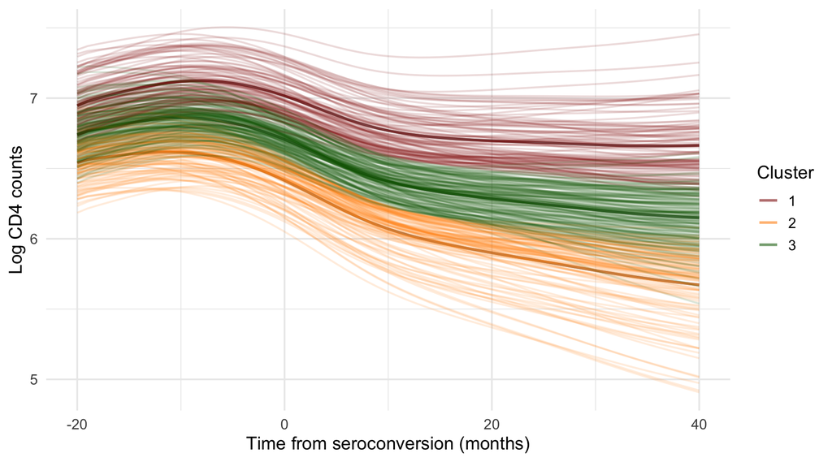

```r
# ─────────────────── Plot ─────────────
tf_plot_clusters_tf(cluster_tbl, centers_tbl)
```

# US all-cause excess and Covid-19 mortality

```r
# ─ Packages ───────────────────
#List of required packages
packages <- c(
  "refund",
  "tidyverse",
  "tidyfun",
  "scales",
  "usmap",
  "sf",
  "viridis",
  "factoextra",
  "mclust"
)

#Install missing packages
install_if_missing <- function(pkg) {
  if (!requireNamespace(pkg, quietly = TRUE)) {
    install.packages(pkg)
  }
}

#Install missing packages
invisible(lapply(packages, install_if_missing))

library(refund)
library(tidyfun)
library(tidyverse)
library(scales)
library(usmap)
library(sf)
library(viridis)
library(factoextra)
library(mclust)
```

```r
# ─── Data ────────────────────────────
#Load data
data("COVID19", package = "refund")
names(COVID19)
##  [1] "US_weekly_mort"                      "US_weekly_mort_dates"
##  [3] "US_weekly_mort_CV19"                 "US_weekly_mort_CV19_dates"
##  [5] "US_weekly_excess_mort_2020"          "US_weekly_excess_mort_2020_dates"
##  [7] "US_states_names"                     "US_states_population"
##  [9] "States_excess_mortality"             "States_excess_mortality_per_million"
## [11] "States_CV19_mortality"               "States_CV19_mortality_per_million"

states <- COVID19$US_states_names
current_date <- COVID19$US_weekly_excess_mort_2020_dates
Wd <- COVID19$States_excess_mortality_per_million
reference_date <- as.Date("2020-01-01")
```

```r
# ──helpers───────────────────
#Converts calendar dates to numeric values
#The tfd requires numeric values and not as dates values.
num_grid <- function(dates, ref = min(dates)) as.numeric(dates - ref)

num_grid_v2 <- function(dates, ref = as.Date("2020-01-01")) as.numeric(dates - ref)
tnum <- num_grid_v2(current_date)
```

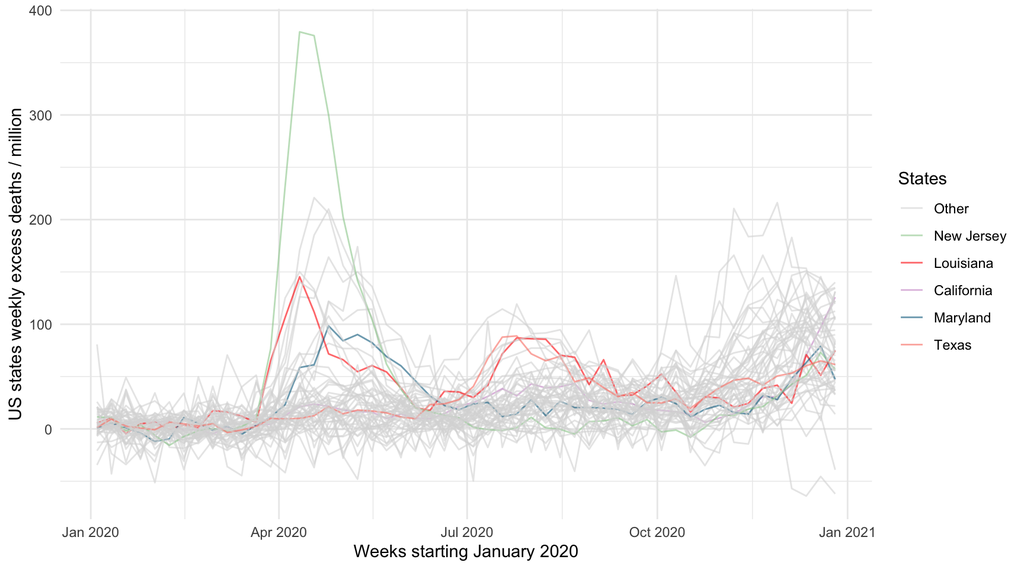

```r
# ───Data Transformation ─────────────
#Organize highlighted the states and their curves
df_tibble <- tibble(
  state     = states,
  #the curves
  mortality = tfd(Wd, arg = tnum)
) %>%
  mutate(
    highlight = if_else(
      state %in% c("New Jersey","Louisiana","California","Maryland","Texas"),
      state, "Other"
    ),
    highlight = factor(highlight, levels = c("Other",
                                             "New Jersey","Louisiana","California","Maryland","Texas"))
  )

## # A tibble: 52 × 3
##    state                                                  mortality highlight
##    <chr>                                                  <tfd_reg> <fct>
##  1 Alabama               [1]: ( 3,  0.8);(10,  7.5);(17,-15.2); ... Other
##  2 Alaska                [2]: ( 3,   -5);(10,   25);(17,    7); ... Other
##  3 Arizona               [3]: ( 3,   -7);(10,    6);(17,    6); ... Other
##  4 Arkansas              [4]: ( 3,   -7);(10,   28);(17,   -1); ... Other
##  5 California            [5]: ( 3,    5);(10,    2);(17,    4); ... California
##  6 Colorado              [6]: ( 3,    3);(10,    7);(17,    4); ... Other
##  7 Connecticut           [7]: ( 3,  0.3);(10,  0.8);(17,  3.1); ... Other
##  8 Delaware              [8]: ( 3,   14);(10,   -1);(17,   -9); ... Other
##  9 District of Columbia  [9]: ( 3,    3);(10,    8);(17,   49); ... Other
## 10 Florida              [10]: ( 3,    6);(10,   10);(17,    8); ... Other
## # ℹ 42 more rows

cols <- c(
  "Other"      = "grey85",
  "New Jersey" = "darkseagreen3",
  "Louisiana"  = "red",
  "California" = "plum3",
  "Maryland"   = "deepskyblue4",
  "Texas"      = "salmon"
)

# ─── Plot ────────────────────────────────
#Exploratory plots and analyses

ggplot(df_tibble) +
  geom_spaghetti(aes(y = mortality, colour = highlight, group = state),alpha =0.6) +
  scale_colour_manual(values = cols, name = "States") +
  scale_x_continuous(
    name = "Weeks starting January 2020",
    breaks = as.numeric(seq(reference_date, as.Date("2021-01-01"), by = "3 months") - reference_date),
    labels = format(seq(reference_date, as.Date("2021-01-01"), by = "3 months"), "%b %Y")
  ) +
  labs(y = "US states weekly excess deaths / million") +
  theme_minimal()
```

Mean and median calculations provide essential summary statistics and are a key part of exploratory data analysis, helping to numerically describe the central tendency of eexcess mortality rate per one million residents for several weeks across 52 states and territories.Thus a complement and help to interpret the visual patterns seen in scatterplots.

```r
# ────────── Summary of Analysis──────────────────────
Wd_tfd <- tfd(Wd, arg = tnum)
# Extract values at week 10 for all states
week10_vals <- Wd_tfd[, tnum[10]]

mean_week10   <- mean(week10_vals, na.rm = TRUE)
## [1] 3.302119
median_week10 <- median(week10_vals, na.rm = TRUE)
## [1] 2.626611
```

On March 7, 2020 (week 10), the excess mortality rate was 3.3 deaths per million on average, with a median of 2.63 deaths per million.

```r
week10 <- Wd[, 10]
ind_out <- which.max(week10_vals)
# Get the name of that state
state_out <- states[ind_out]
val_out <- round(Wd_tfd[ind_out, tnum[6:14]], 1)
```

An outlier was observed in North Dakota on week 10. The state’s excess mortality rates from weeks 6 to 14 were: 10.5, -17, 49.7, 10.5, 70.6, 39.2, 6.5, -30.1, -41.8 excess mortality.

Identify the five states with the highest weekly excess mortality rates on week 20.

```r
# ---- Top 5 states at week 20 ----
vals20 <- Wd_tfd[, tnum[20]]
ord20  <- order(vals20)
topweek20 <- round(vals20[ord20][48:52], 1)
states_top_20 <- states[ord20][48:52]
```

For week 20, the five states with the highest excess mortality rates per million residents were the District of Columbia (136.1), Massachusetts (122.1), Delaware (114.5), Connecticut (106.3), and New Jersey (104.5), in descending order.

```r
# ---- Top 5 states at week 30 ----
vals30 <- Wd_tfd[, tnum[30]]
ord30  <- order(vals30)
topweek30 <- round(vals30[ord30][48:52], 1)
states_top_30 <- states[ord30][48:52]

topweek30
```

```
## [1]  84.7  87.0  88.8 107.0 119.3
```

```r
states_top_30
```

```
## [1] "South Carolina" "Louisiana"      "Texas"          "Arizona"
## [5] "Mississippi"
```

```r
# ---- Top 5 states at week 40 ----
vals40 <- Wd_tfd[, tnum[40]]
ord40  <- order(vals40)
topweek40 <- round(vals40[ord40][48:52], 1)
states_top_40 <- states[ord40][48:52]

topweek40
```

```
## [1] 53.2 58.4 58.9 72.3 75.8
```

```r
states_top_40
```

```
## [1] "Wyoming"              "Missouri"             "District of Columbia"
## [4] "Arkansas"             "North Dakota"
```

#### K-means clustering of the functional data

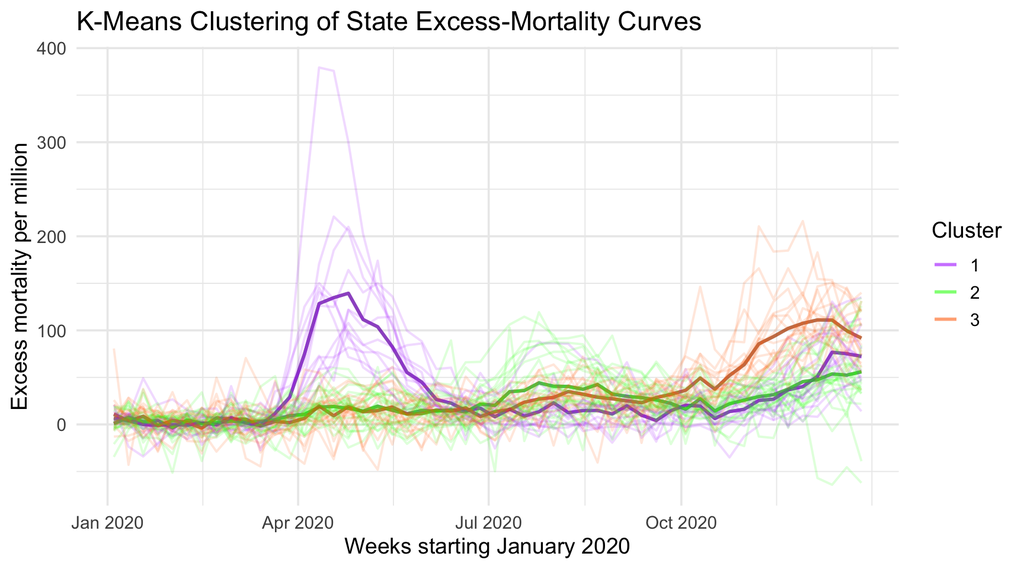

```r
# ──────────────── K-means clustering of the functional data ──────────────────────────────

rownames(Wd) <- states
set.seed(1000)
km    <- kmeans(Wd, centers = 3)
cl_ind <- km$cluster
cl_cen <- km$centers



##  ─── Build tidyfun objects ──────────────────────
pred_tf    <- tfd(Wd, arg = tnum)

centers_tf <- tfd(cl_cen, arg = tnum)

# Create tibbles
cluster_tbl <- tf_join_clusters_tf(pred_tf, cl_ind)
centers_tbl <- tibble(
  cluster = factor(seq_len(nrow(cl_cen))),
  curve   = centers_tf
)

# Plot with corrected date handling
tf_plot_clusters_tf(cluster_tbl, centers_tbl) +
  scale_color_manual(
    values = c("#AA00FF","green", "#FF6D00"),
    name   = "Cluster"
  ) +
  scale_x_continuous(
    breaks = function(x) {
      # Use 2020-01-01 as reference for quarterly breaks
      reference_date <- as.Date("2020-01-01")
      start_date <- reference_date  # Start from Jan 1, 2020
      end_date <- max(current_date)
      quarterly_dates <- seq(from = start_date, to = end_date, by = "3 months")
      # Convert to your numeric scale (days since 2020-01-01)
      as.numeric(quarterly_dates - reference_date)
    },
    labels = function(x) {
      # Convert back to dates using 2020-01-01 as reference
      reference_date <- as.Date("2020-01-01")
      d <- reference_date + x
      format(d, "%b %Y")
    },
    name = "Weeks starting January 2020"
  ) +
  labs(
    y = "Excess mortality per million",
    title = "K-Means Clustering of State Excess-Mortality Curves"
  ) +
  theme_minimal(base_size = 14)
```